# ESM244 Assignment3

Craig O’Neill

March 12, 2018

```r
library(tidyverse)
library(forecast)
library(tseries)
library(sf)
library(tmap)
```

## Task 3

# a) Create a graph of the decomposed time series data (tuckee_flow). In text beneath the graph describe the time series data.

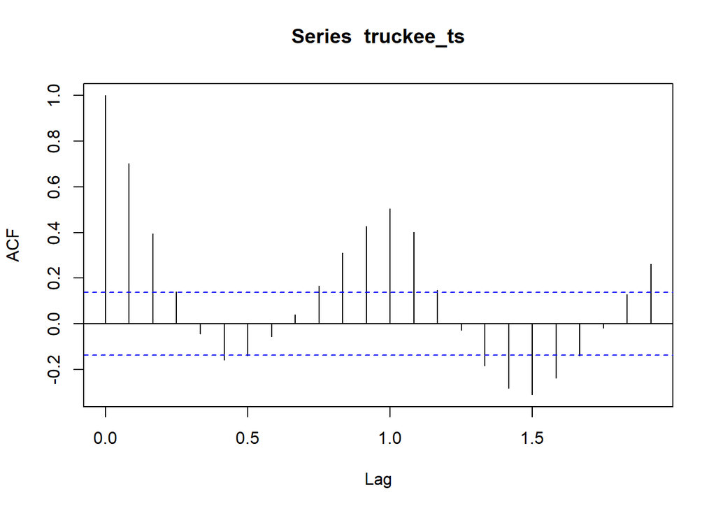

```r
truckee <- read.csv("truckee_flow-edit.csv")

truckee_ts <- ts(truckee$mean_va, frequency = 12, start = c(2000, 1))

truckee_dc <- decompose(truckee_ts, type = "additive")
acf(truckee_ts)
```

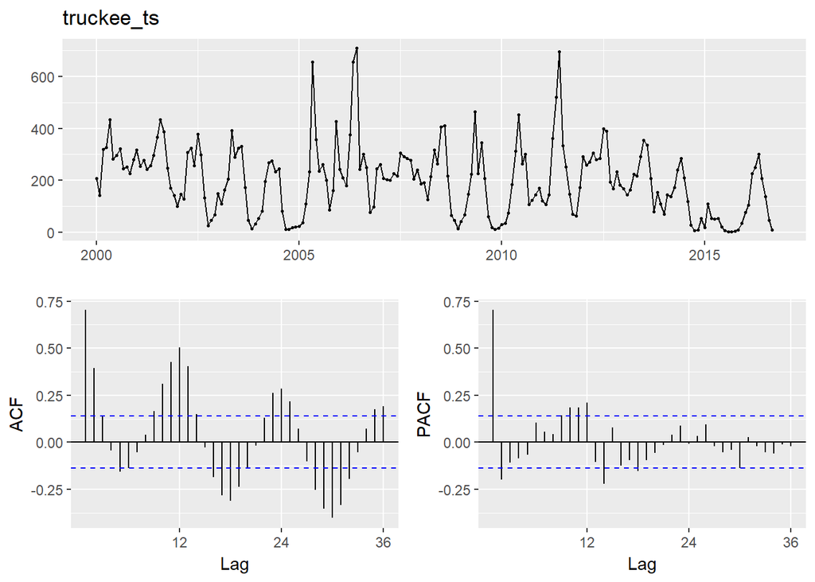

```r
ggtsdisplay(truckee_ts)
```

```r
adf_truckee <- adf.test(truckee_ts)
adf_truckee
```

```
##
##  Augmented Dickey-Fuller Test
##
## data:  truckee_ts
## Dickey-Fuller = -5.5387, Lag order = 5, p-value = 0.01
## alternative hypothesis: stationary
```

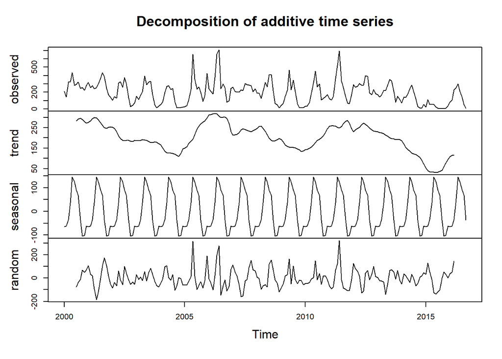

```r
plot(truckee_dc)
```

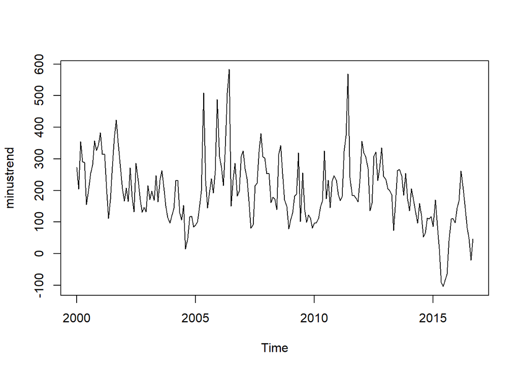

```r
minustrend <- truckee_dc$x - truckee_dc$seasonal
plot(minustrend)
```

Part a Response:

The time series data for Truckee discharge is stationary with an annual seasonality. A Dickey-Fuller test was used to test the data, a p-value of 0.01 was found indicating that the data is not non-stationary. The data appears to be additive, as confirmed by the even distribution of residuals in the decomposed dataset. There appears to be a longer term cyclical trend beyond the annual seasonality, this longer term cyclical trend appears to be occuring every 5 years. There also appears to be an outlier in the data occuring shortly after 2015.

Part a cut content: Decomposing the time series data for the Truckee discharge

The data appears to have annual seasonality.

# b) Use either Holt-Winters of ARIMA to forecast Truckee River for 5 years after the final observation. Visualize the forecasted data in a graph.

First Holt-Winters

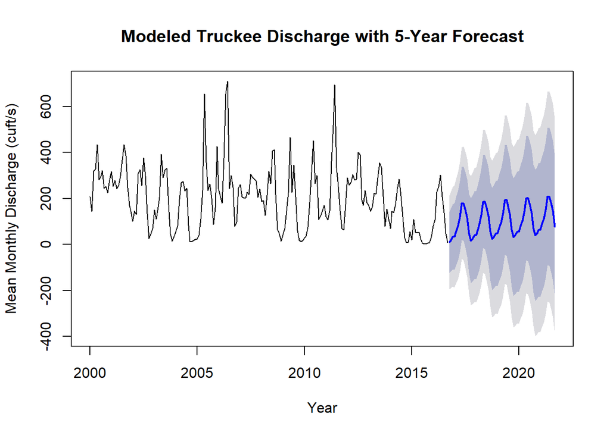

```r
truckee_hw <- HoltWinters(truckee_ts)
#hw_fc_60 <- predict(truckee_hw, n.ahead = 60, prediction.interval = T, level = 0.95)
#plot(truckee_hw, hw_fc_60)

truckee_holtfc <- forecast(truckee_hw, h = 60)
plot(truckee_holtfc,
     main = "Modeled Truckee Discharge with 5-Year Forecast",
     xlab = "Year",
     ylab = "Mean Monthly Discharge (cuft/s)")
```

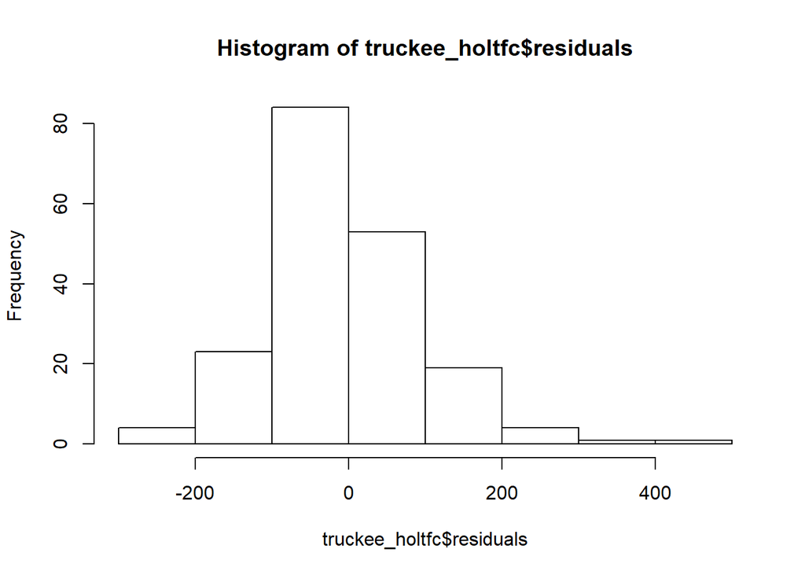

```r
hist(truckee_holtfc$residuals)
```

Part B) Response (Graphs above)

Next ARIMA

```r
truckee_pdq <- auto.arima(truckee_ts)
truckee_pdq
```

```
## Series: truckee_ts
## ARIMA(3,1,4)(0,0,1)[12]
##
## Coefficients:
##          ar1      ar2     ar3      ma1     ma2      ma3     ma4    sma1
##       2.4054  -2.1585  0.6722  -2.7717  2.7951  -1.0522  0.0336  0.2230
## s.e.  0.1122   0.1964  0.1150   0.1555  0.4059   0.3965  0.1459  0.0722
##
## sigma^2 estimated as 7413:  log likelihood=-1173.33
## AIC=2364.66   AICc=2365.61   BIC=2394.35
```

ARIMA (3,1,4)(0,0,1)

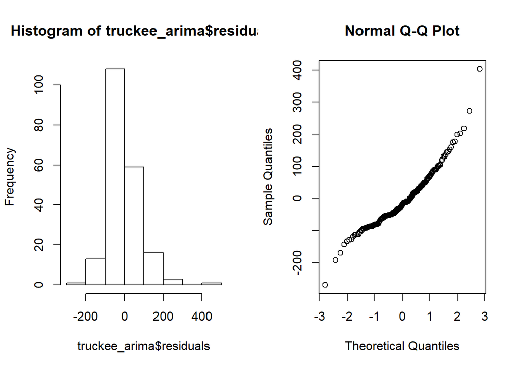

```r
truckee_arima <- arima(truckee_ts, order = c(3,1,4), seasonal = list(order = c(0,0,1)))

par(mfrow = c(1,2))
hist(truckee_arima$residuals)
qqnorm(truckee_arima$residuals)
```

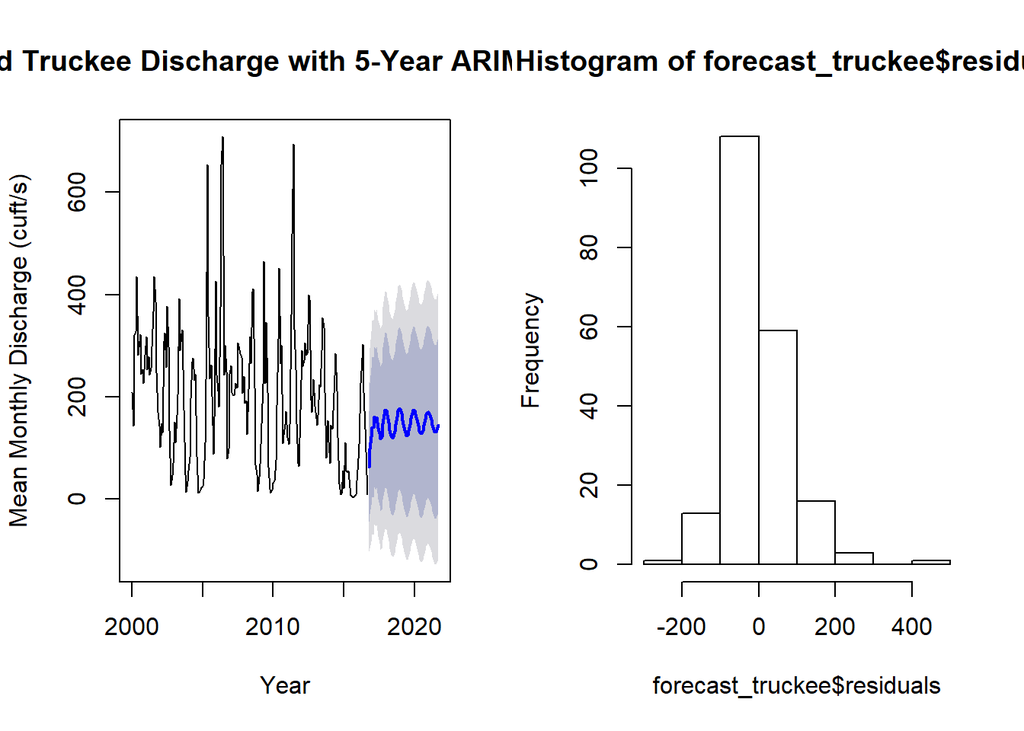

```r
forecast_truckee <- forecast(truckee_arima, h = 60)
plot(forecast_truckee,
     main = "Modeled Truckee Discharge with 5-Year ARIMA Forecast",
     xlab = "Year",
     ylab = "Mean Monthly Discharge (cuft/s)")

hist(forecast_truckee$residuals)
```

## Task 4 Mapping California’s National Parks

```r
ca_shape <- st_read(dsn = ".", layer = "california_county_shape_file")
st_crs(ca_shape) <- 4326

np_shape <- st_read(dsn = ".", layer = "nps_boundary")
np_shape <- st_transform(np_shape, "+init=epsg:4326")


canp_shape <- np_shape %>%
  filter(STATE == "CA") %>%
  filter(UNIT_TYPE == "National Park") %>%
  select(UNIT_NAME, STATE, UNIT_TYPE, geometry)
```

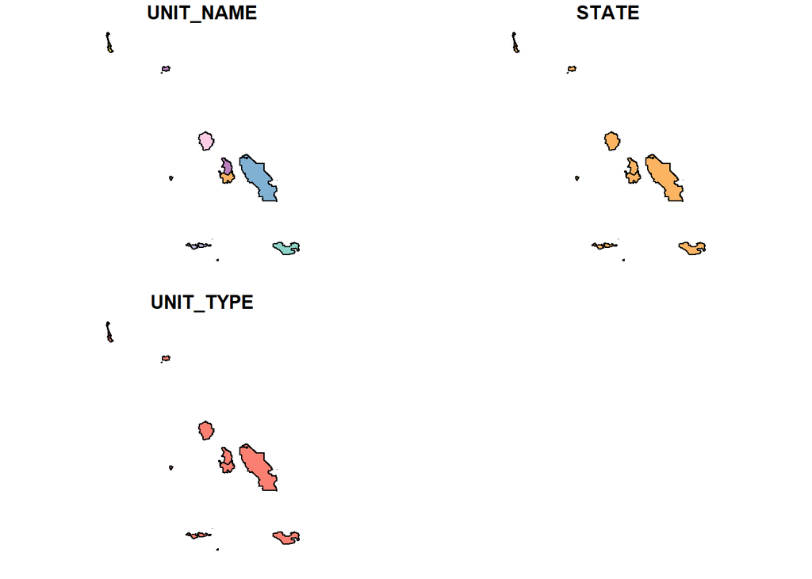

```r
View(ca_shape)
plot(canp_shape)
```

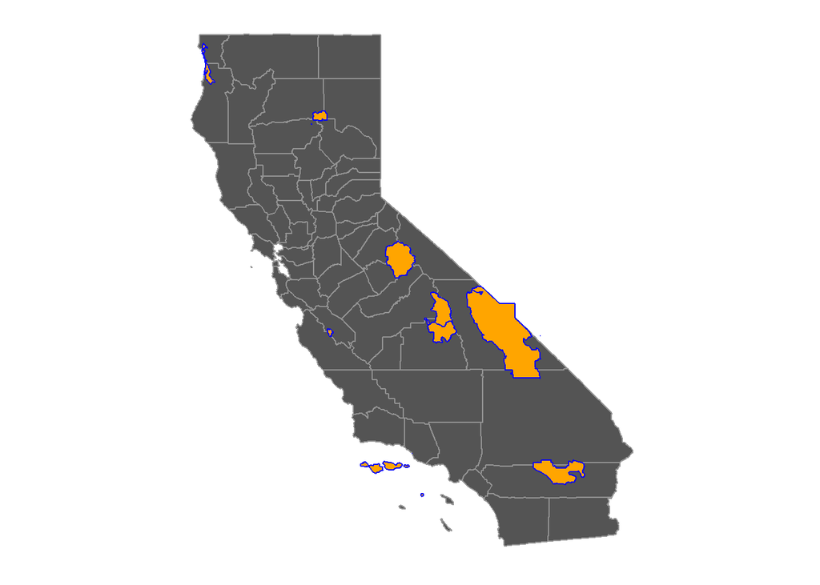

```r
ca_np_gg <- ggplot(canp_shape)+
  geom_sf(data = ca_shape, aes(fill = STATE), color = "gray58", fill = "gray33")+
  geom_sf(aes(color = UNIT_TYPE, fill = UNIT_TYPE), color = "blue", fill = "orange")+
  theme(axis.text.x = element_blank(),
        axis.text.y = element_blank(),
        axis.ticks = element_blank(),
        rect = element_blank(),
        panel.grid.major = element_line(color = "transparent"))

ca_np_gg
```

### Task 5 LTER Lizards in the Northern Chihuahuan Desert

```r
library(VIM)
library(mice)
```

1. For all lizards at site “CALI”, do weights of male and female ault lizards differ significantly?

```r
lizard <- read.csv("lter_lizard_pitfall_edited.csv")

lizard_cal <- lizard %>%
  filter(site == "CALI") %>%
  select(date, site, sex, weight, tail)

lizard_cal$site <- as.factor(lizard_cal$site)
lizard_cal$tail <- as.factor(lizard_cal$tail)
lizard_cal$sex <- as.factor(lizard_cal$sex)
```

Identify missing cases

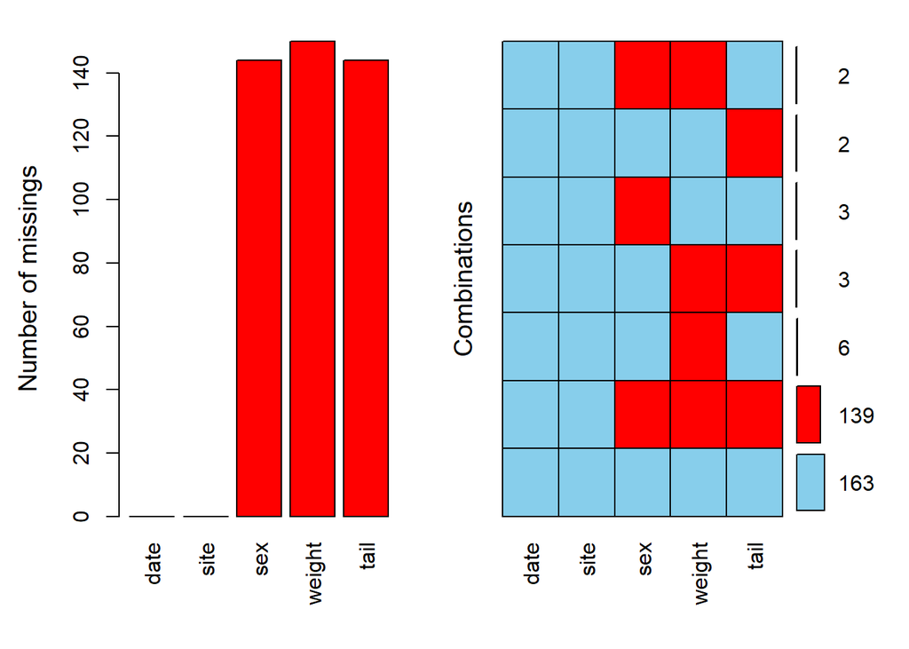

```r
liz_cc <- lizard_cal[complete.cases(lizard_cal),] #this extra comma tells R to just look at the rows of data.
liz_missings <- lizard_cal[!complete.cases(lizard_cal),]

aggr(lizard_cal, prop = F, numbers = T)
```

```r
imputed_liz <- mice(lizard_cal, m = 5)
summary(imputed_liz)
```

```
## Multiply imputed data set
## Call:
## mice(data = lizard_cal, m = 5)
## Number of multiple imputations:  5
## Missing cells per column:
##   date   site    sex weight   tail
##      0      0    144    150    144
## Imputation methods:
##      date      site       sex    weight      tail
##        ""        "" "polyreg"     "pmm"  "logreg"
## VisitSequence:
##    sex weight   tail
##      3      4      5
## PredictorMatrix:
##        date site sex weight tail
## date      0    0   0      0    0
## site      0    0   0      0    0
## sex       1    0   0      1    1
## weight    1    0   1      0    1
## tail      1    0   1      1    0
## Random generator seed value:  NA
```

COmpete the cases using imputed cvalues

```r
com_liz <- complete(imputed_liz, action = 2)
```

```r
lm_liz <- with(imputed_liz, lm(weight ~ sex))
impute_pooled_liz <- pool(lm_liz)

impute_pooled_liz
```

```
## Call: pool(object = lm_liz)
##
## Pooled coefficients:
## (Intercept)        sex2        sex3
##   5.3421786  -3.4128988  -0.6897952
##
## Fraction of information about the coefficients missing due to nonresponse:
## (Intercept)        sex2        sex3
##   0.8549756   0.7283497   0.7808765
```

```r
summary(impute_pooled_liz)
```

```
##                    est        se          t       df   Pr(>|t|)     lo 95
## (Intercept)  5.3421786 0.8925174  5.9855177 5.522169 0.00131741  3.111631
## sex2        -3.4128988 1.1670705 -2.9243295 8.217582 0.01861800 -6.091815
## sex3        -0.6897952 1.0800468 -0.6386716 6.973783 0.54343379 -3.245648
##                  hi 95 nmis       fmi    lambda
## (Intercept)  7.5727260   NA 0.8549756 0.8105043
## sex2        -0.7339825   NA 0.7283497 0.6694079
## sex3         1.8660572   NA 0.7808765 0.7259155
```

```r
#combined_liz <- complete(impute_pooled_liz)
```

1. For All Lizards trapped at site CALI do weights of male and female adult lizards

```r
liz_cc_f <- liz_cc %>%
  filter(sex == "F")
liz_cc_m <- liz_cc %>%
  filter(sex == "M")


t.test(liz_cc_f$weight, liz_cc_m$weight)
```

```
##
##  Welch Two Sample t-test
##
## data:  liz_cc_f$weight and liz_cc_m$weight
## t = 0.6825, df = 123.53, p-value = 0.4962
## alternative hypothesis: true difference in means is not equal to 0
## 95 percent confidence interval:
##  -1.398063  2.869579
## sample estimates:
## mean of x mean of y
##  5.826667  5.090909
```

```r
liz_cc_f <- com_liz %>%
  filter(sex == "F")
liz_cc_m <- com_liz %>%
  filter(sex == "M")


t.test(liz_cc_f$weight, liz_cc_m$weight)
```

```
##
##  Welch Two Sample t-test
##
## data:  liz_cc_f$weight and liz_cc_m$weight
## t = -0.66698, df = 169.23, p-value = 0.5057
## alternative hypothesis: true difference in means is not equal to 0
## 95 percent confidence interval:
##  -1.756303  0.869221
## sample estimates:
## mean of x mean of y
##  4.129630  4.573171
```

Task 5 A)

2. For lizards trapped at CALI site, is there a significant difference in the proportion of adult male and female lizards with broken tails?

```r
liz_cc_con <- com_liz %>%
  select(sex, tail) %>%
  filter(sex != "J")

table1 <- table(liz_cc_con)
table2 <- table1[-2,]

View(table2)

chisq <- chisq.test(table2)
chisq
```

```
##
##  Pearson's Chi-squared test with Yates' continuity correction
##
## data:  table2
## X-squared = 10.355, df = 1, p-value = 0.001291
```

Task 5 1)